# DATA 606: Homework Presentation

Kavya Beheraj

March 13, 2018

# **4.3 College Credits**

### A college counselor is interested in estimating how many credits a student typically enrolls in each semester. The counselor decides to randomly sample 100 students by using the registrar’s database of students. The histogram below shows the distribution of the number of credits taken by these students. Sample statistics for this distribution are also provided.

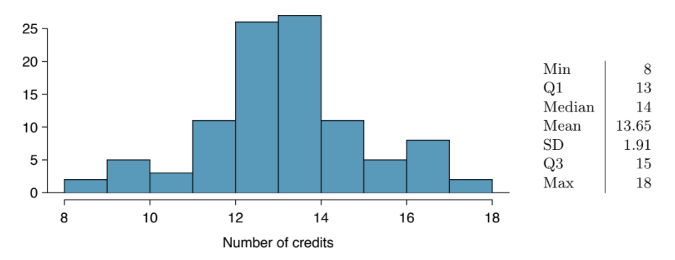

#### **(b)** What is the point estimate for the standard deviation of the number of credits taken per semester by students at this college? What about the IQR?

- Standard deviation point estimate = standard deviation of sample = **1.91**
- IQR = 15-13 = **2**

#### **(c)** Is a load of 16 credits unusually high for this college? What about 18 credits? Explain your reasoning. *Hint: Observations farther than two standard deviations from the mean are usually considered to be unusual.*

- Since the mean is 13.65 and the standard deviation is 1.91, 16 credits occurs about 1.2 standard deviations obove the mean. This is not too unusual.

```r
(16 - 13.65) / 1.91
```

```
## [1] 1.230366
```

- 18 credits occurs about 2.3 standard deviations above the mean. This is unusual.

```r
(18 - 13.65) / 1.91
```

```
## [1] 2.277487
```

#### **(d)** The college counselor takes another random sample of 100 students and this time finds a sample mean of 14.02 units. Should she be surprised that this sample statistic is slightly different than the one from the original sample? Explain your reasoning.

- She should not be surprised, because sample means vary from one population to another. They only approximate the population parameter.

#### **(e)** The sample means given above are point estimates for the mean number of credits taken by all students at that college. What measures do we use to quantify the variability of this estimate? Compute this quantity using the data from the original sample.

```r
13.65 / sqrt(100)
```

```
## [1] 1.365
```